# P&S-2021: Lab assignment 2

Revera, Sukhorskyy, Shabatska

## Efforts:

- Task 1: Yaroslav Revera, Daria Shabatska
- Task 2: Yaroslav Revera
- Task 3: Yurii Sukhorskyy

### Task 1

#### In this task, we discuss the $[7,4]$ Hamming code and investigate its reliability. That coding system can correct single errors in the transmission of $4$-bit messages and proceeds as follows:

- given a message $\mathbf{m} = (a_1 a_2 a_3 a_4)$, we first encode it to a $7$-bit *codeword* $\mathbf{c} = \mathbf{m}G = (x_1 x_2 x_3 x_4 x_5 x_6 x_7)$, where $G$ is a $4\times 7$ *generator* matrix
- the codeword $\mathbf{c}$ is transmitted, and $\mathbf{r}$ is the received message
- $\mathbf{r}$ is checked for errors by calculating the *syndrome vector* $\mathbf{z} := \mathbf{r} H$, for a $7 \times 3$ *parity-check* matrix $H$
- if a single error has occurred in $\mathbf{r}$, then the binary $\mathbf{z} = (z_1 z_2 z_3)$ identifies the wrong bit no. $z_1 + 2 z_2 + 4z_3$; thus $(0 0 0)$ shows there was no error (or more than one), while $(1 1 0 )$ means the third bit (or more than one) got corrupted
- if the error was identified, then we flip the corresponding bit in $\mathbf{r}$ to get the corrected $\mathbf{r}^* = (r_1 r_2 r_3 r_4 r_5 r_6 r_7)$;
- the decoded message is then $\mathbf{m}^*:= (r_3r_5r_6r_7)$.

#### The **generator** matrix $G$ and the **parity-check** matrix $H$ are given by

$$G :=
\begin{pmatrix}
1 & 1 & 1 & 0 & 0 & 0 & 0 \\
1 & 0 & 0 & 1 & 1 & 0 & 0 \\
0 & 1 & 0 & 1 & 0 & 1 & 0 \\
1 & 1 & 0 & 1 & 0 & 0 & 1 \\
\end{pmatrix},
\qquad
H^\top := \begin{pmatrix}
1 & 0 & 1 & 0 & 1 & 0 & 1 \\
0 & 1 & 1 & 0 & 0 & 1 & 1 \\
0 & 0 & 0 & 1 & 1 & 1 & 1
\end{pmatrix}$$

#### Assume that each bit in the transmission $\mathbf{c} \mapsto \mathbf{r}$ gets corrupted independently of the others with probability $p = \mathtt{id}/100$, where $\mathtt{id}$ is your team number. Your task is the following one.

1. Simulate the encoding-transmission-decoding process $N$ times and find the estimate $\hat p$ of the probability $p^*$ of correct transmission of a single message $\mathbf{m}$. Comment why, for large $N$, $\hat p$ is expected to be close to $p^*$.
2. By estimating the standard deviation of the corresponding indicator of success by the standard error of your sample and using the CLT, predict the interval $(p^*-\varepsilon, p^* + \varepsilon)$, in which the estimate $\hat p$ falls with probability at least $0.95$.
3. What choice of $N$ guarantees that $\varepsilon \le 0.03$?
4. Draw the histogram of the number $k = 0,1,2,3,4$ of errors while transmitting a $4$-digit binary message. Do you think it is one of the known distributions?

#### First, we set the **id** of the team and define the probability $p$ and the generator and parity-check matrices $G$ and $H$

```r
id <- 8

set.seed(id)
p <- id/100

G <- matrix(c(1, 1, 1, 0, 0, 0, 0,
        1, 0, 0, 1, 1, 0, 0,
        0, 1, 0, 1, 0, 1, 0,
        1, 1, 0, 1, 0, 0, 1), nrow = 4, byrow = TRUE)
H <- t(matrix(c(1, 0, 1, 0, 1, 0, 1,
        0, 1, 1, 0, 0, 1, 1,
        0, 0, 0, 1, 1, 1, 1), nrow = 3, byrow = TRUE))
```

#### Next, implement the function that generates the messages, errors, and performs encoding-transmission-decoding process. It returns list of two objects - probability of correctly transmitted messages (floating point value) and vector of integer numbers of errors in each message (length of this vector is N - number of messages)

```r
num_messages = 5

simulate <- function(){

  # generate N messages
  message_generator <- function(N) {
    matrix(sample(c(0,1), 4*N, replace = TRUE), nrow = N)
  }
  messages <- message_generator(num_messages)
  codewords <- (messages %*% G) %% 2

  # generate errors
  errors_generator <- function(N){
    matrix(sample(c(0,1), 7*N, replace = TRUE, prob = c(1-p, p)), nrow = N)
  }

  errors <- errors_generator(num_messages)
  received <- (codewords + errors) %% 2

  ZZ = (received%*%H) %%2

  # get wrong bits indices in transmitted message as integers
  wrong <- strtoi(apply(ZZ, 1, function(row) paste(row, collapse = "")), base = 2) + 1

  decoded <- received
  # correct received messages
  for (i in seq(1:nrow(decoded))){
    if(wrong[i] < 8){
      decoded[i, wrong[i]] <- xor(decoded[i, wrong[i]], 1)
    }
  }
  decoded_messages = decoded[, c(3,5,6,7)]      # data bits
  comparisons <- decoded_messages == messages

  errors_count_vector = vector(length = num_messages)
  errors_count = 0
  i = 0
  c = 0
  err_c_temp = 0
  num_correct = 0

  # count number of errors, build errors_count_vector, count number of correctly transmitted messages
  for(cmp in comparisons){
    if(c%%4 == 0){
      errors_count_vector[i] = err_c_temp
      i=i+1
      errors_count = errors_count + err_c_temp
      if(err_c_temp == 0)
        num_correct = num_correct+1
      err_c_temp = 0
    }
    if(cmp == FALSE){
      err_c_temp = err_c_temp+1
    }
    c=c+1
  }
  prob_of_correct = num_correct/num_messages

  return(list(prob_of_correct, errors_count_vector))
}

simulate()
```

```
## [[1]]
## [1] 0.6
##
## [[2]]
## [1] 2 0 0 1 0
```

#### Now we perform 100 experiments with 100 messages in each experiment to build histogram and calculate mean probability of correct transmission

```r
num_messages = 100
num_sims = 100

init_sim_res = simulate()
mean_prob <- init_sim_res[[1]]
err_count <- init_sim_res[[2]]

for (i in 1:num_sims-1) {
  sim_res   <- simulate()
  mean_prob <- (mean_prob + sim_res[[1]]) / 2
  err_count <- c(err_count, sim_res[[2]])
}
print(mean_prob)
```

```
## [1] 0.6517224
```

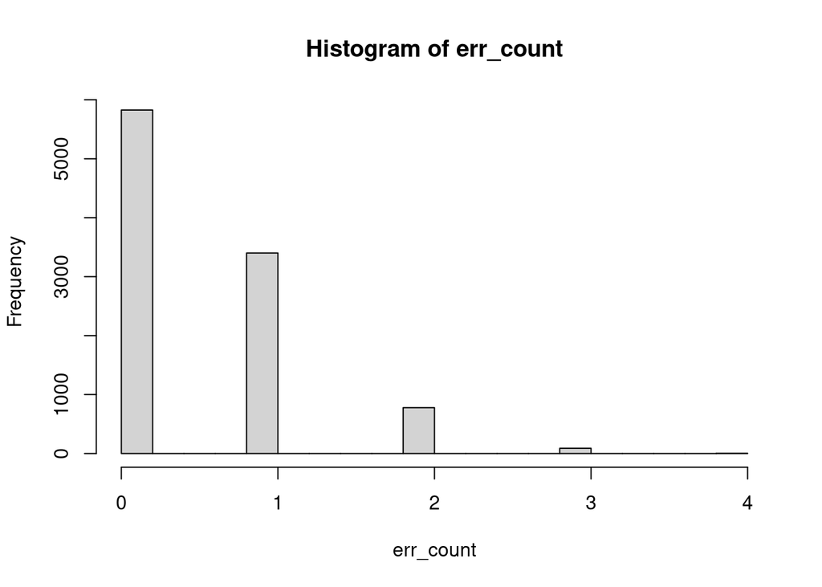

```r
hist(err_count, xlim=c(0, 4), freq=T)
```

So the probability that we will have more errors decreases: we have the least probability that we will have 4 errors, a bit higher that we will have 3 errors, etc., which agreed with common sence

#### Predict epsilon which forms the interval in which the estimate $\hat p$ falls with probability at least $0.95$ and find N that guarantees that $\varepsilon \le 0.03$

CTL states that $P(\frac{S_n - n \mu}{\sigma \sqrt{n}} \le t) \rightarrow Ф(t)$, where $S_n = X_{1} + X_{2} + ... + X_{n}$. Given that $P(\hat p - p^{*} \le \epsilon)) = Ф(\frac{\epsilon \sqrt{n}}{\sigma})$ we can derive that $Ф(\frac{\epsilon \sqrt{n}}{\sigma}) \ge \frac{1.95}{2}$. As `R`’s `qnorm` function is opposite to normal distribution, $\epsilon \ge qnorm(\frac{1.95}{2}) \frac{\sigma}{\sqrt{n}}$

```r
N <- 100
std_dev <- sd(err_count == 0)
std_err <- sqrt(N)
eps <- qnorm(0.95, 0, 1) * std_dev / std_err
cat("For N =", N, "epsilon =", eps, "\n")
```

```
## For N = 100 epsilon = 0.0812674
```

```r
N_ <- round((std_dev * qnorm(0.975, 0, 1) / eps) ** 2, 0)
cat("N =", N_, "guarantees that epsilon <= 0.03\n")
```

[output not shown]

### Task 2.

#### In this task, we discuss a real-life process that is well modelled by a Poisson distribution. As you remember, a Poisson random variable describes occurrences of rare events, i.e., counts the number of successes in a large number of independent random experiments. One of the typical examples is the **radioactive decay** process.

#### Consider a sample of radioactive element of mass $m$, which has a big *half-life period* $T$; it is vitally important to know the probability that during a one second period, the number of nuclei decays will not exceed some critical level $k$. This probability can easily be estimated using the fact that, given the *activity* ${\lambda}$ of the element (i.e., the probability that exactly one nucleus decays in one second) and the number $N$ of atoms in the sample, the random number of decays within a second is well modelled by Poisson distribution with parameter $\mu:=N\lambda$. Next, for the sample of mass $m$, the number of atoms is $N = \frac{m}{M} N_A$, where $N_A = 6 \times 10^{23}$ is the Avogadro constant, and $M$ is the molar (atomic) mass of the element. The activity of the element, $\lambda$, is $\log(2)/T$, where $T$ is measured in seconds.

#### Assume that a medical laboratory receives $n$ samples of radioactive element ${{}^{137}}\mathtt{Cs}$ (used in radiotherapy) with half-life period $T = 30.1$ years and mass $m = \mathtt{team\, id \,number} \times 10^{-6}$ g each. Denote by $X_1,X_2,\dots,X_n$ the **i.i.d. r.v.**’s counting the number of decays in sample $i$ in one second.

1. Specify the parameter of the Poisson distribution of $X_i$ (you’ll need the atomic mass of *Cesium-137*)
2. Show that the distribution of the sample means of $X_1,\dots,X_n$ gets very close to a normal one as $n$ becomes large and identify that normal distribution. To this end,
   - simulate the realization $x_1,x_2,\dots,x_n$ of the $X_i$ and calculate the sample mean $s=\overline{\mathbf{x}}$;
   - repeat this $K$ times to get the sample $\mathbf{s}=(s_1,\dots,s_K)$ of means and form the empirical cumulative distribution function $\hat F_{\mathbf{s}}$ of $\mathbf{s}$;
   - identify $\mu$ and $\sigma^2$ such that the $F$ of $\mathscr{N}(\mu,\sigma^2)$ is close to the $\hat F_{\mathbf{s}}$ and plot both **c.d.f.**’s on one graph to visualize their proximity (use the proper scales!);
   - calculate the maximal difference between the two ’s;
   - consider cases $n = 5$, $n = 10$, $n=50$ and comment on the results.
3. Calculate the largest possible value of $n$, for which the total number of decays in one second is less than $8 \times 10^8$ with probability at least $0.95$. To this end,
   - obtain the theoretical bound on $n$ using Markov inequality, Chernoff bound and Central Limit Theorem, and compare the results;
   - simulate the realization $x_1,x_2,\dots,x_n$ of the $X_i$ and calculate the sum $s=x_1 + \cdots +x_n$;
   - repeat this $K$ times to get the sample $\mathbf{s}=(s_1,\dots,s_K)$ of sums;
   - calculate the number of elements of the sample which are less than critical value ($8 \times 10^8$) and calculate the empirical probability; comment whether it is close to the desired level $0.95$

```r
T = 30.1 * 365.25 * 24 * 3600
lambda = log10(2)/T

id = 8

m = (id) * 1e-6
Na = 6e23
M = 137         # Atomic mass of Cesium-137, obviously
N = (m/M) * Na

mu <- N * lambda
K <- 1e3
n <- 5
sample_means <- colMeans(matrix(rpois(n*K, lambda = mu), nrow=n))
```

#### Next, calculate the parameters of the standard normal approximation

```r
mu1 <- mean(sample_means)
sigma <- sqrt(mean((sample_means - mu1)^2))
```

#### We can now create a function to plot ecdf and cdf and calculate maximal difference

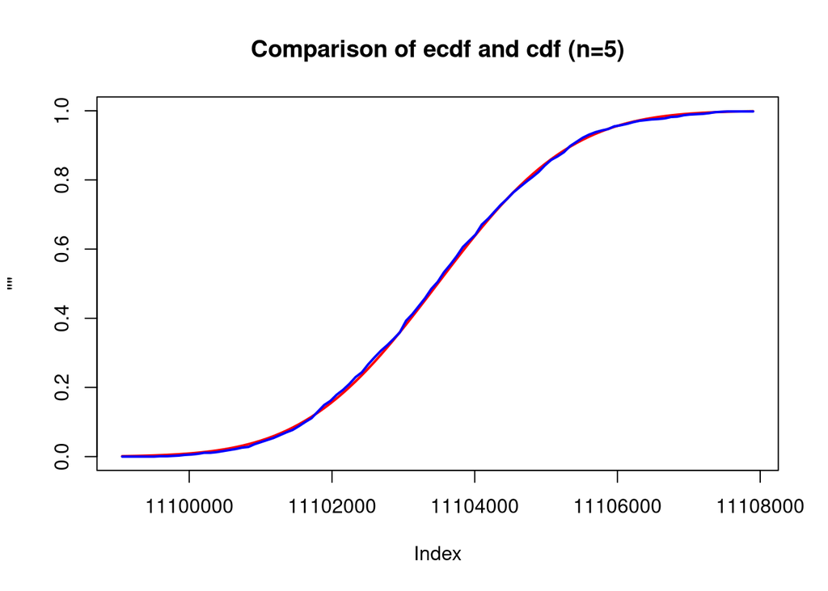

```
## [1] 0.001349898
```

```r
compute4n <- function(n, mu, sample_means){
    xlims <- c(mu-3*sigma,mu+3*sigma)
    Fs <- ecdf(sample_means)
    plot("",
        xlim = xlims,
        ylim = c(0,1),
        col = "blue",
        lwd = 2,
        main = paste("Comparison of ecdf and cdf (n=", n, ")", sep=""))
    curve(pnorm(x, mean = mu, sd = sigma), col = "red", lwd = 2, add = TRUE)
    curve(Fs, col = "blue", lwd = 2, add = TRUE)

    # calculate max difference between two functions
    t <- seq(from = mu - 3*sigma, to = mu + 3*sigma, by = mu / 200)
    max(abs(Fs(t) - pnorm(t, mean = mu, sd = sigma)))
}
compute4n(n, mu1, sample_means)
```

#### Cases for other `n`

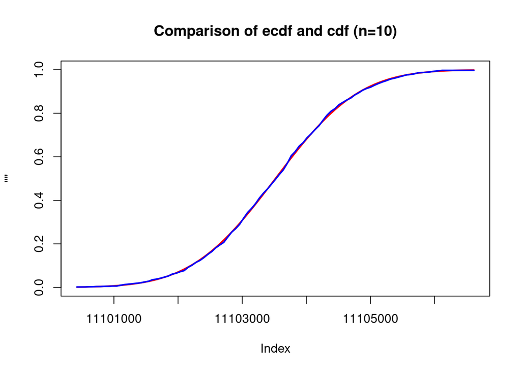

```
## [1] 0.000650102
```

```r
# repeat the experiment for n = 10
n = 10
sample_means <- colMeans(matrix(rpois(n*K, lambda = mu), nrow=n))
mu2 <- mean(sample_means)
sigma <- sqrt(mean((sample_means - mu2)^2))
compute4n(10, mu2, sample_means)
```

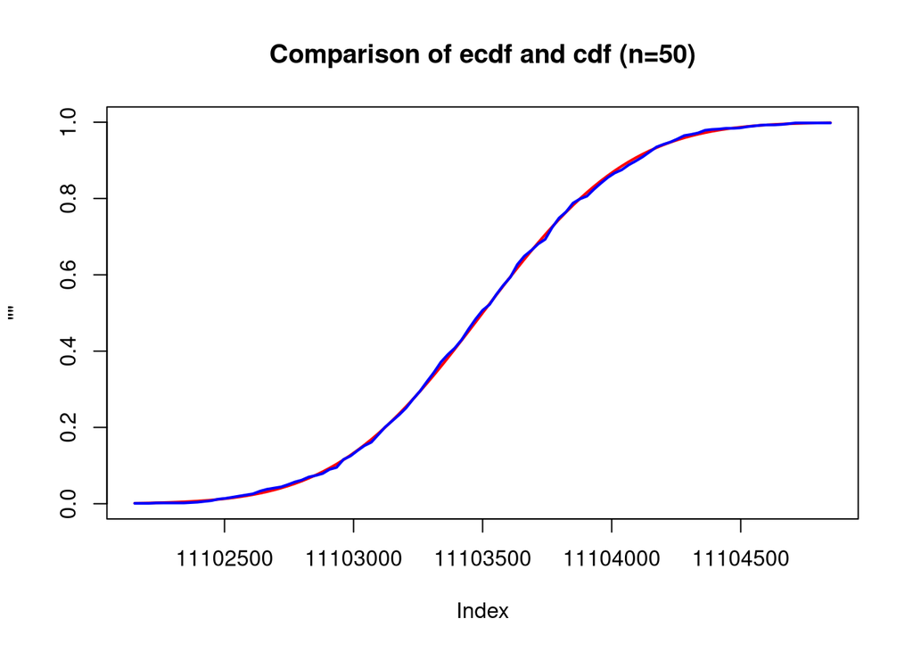

```
## [1] 0.000349898
```

```r
# repeat the experiment for n = 50
n = 50
sample_means <- colMeans(matrix(rpois(n*K, lambda = mu), nrow=n))
mu3 <- mean(sample_means)
sigma <- sqrt(mean((sample_means - mu3)^2))
compute4n(50, mu3, sample_means)
```

Here we can see that with bigger `n` two curves on the graph become closer and closer one to another and we obtain smaller value of max difference between two functions

#### Largest possible `n` for which total number of decays in one second is less than $8 \times 10^8$ with probability of least 0.95

We will use following algorithm to find such `n`

```r
max_value = 8e8

l = 0
r = 1000

m = 0
res_m = 0

defaultW <- getOption("warn")   # Turn off warnings
options(warn = -1)

# reduce window till size 0.00001 trying to find closest n
while(r-l > 0.00001){
  m = (l+r)/2
  sample_sum = colSums(matrix(rpois(m*K, lambda = mu), nrow=m))
  Ps_temp <- ecdf(sample_sum)(max_value)
  if(Ps_temp > 0.95){
    l = m
    Ps = Ps_temp
    res_m = m
  }
  else if(Ps_temp < 0.95){
    r = m
  }
  cat("  n =", m, " with P =", Ps_temp, "\n")    # print step-by-step interim results
}
```

```
##   n = 500  with P = 0
##   n = 250  with P = 0
##   n = 125  with P = 0
##   n = 62.5  with P = 1
##   n = 93.75  with P = 0
##   n = 78.125  with P = 0
##   n = 70.3125  with P = 1
##   n = 74.21875  with P = 0
##   n = 72.26562  with P = 1
##   n = 73.24219  with P = 0
##   n = 72.75391  with P = 1
##   n = 72.99805  with P = 1
##   n = 73.12012  with P = 0
##   n = 73.05908  with P = 0
##   n = 73.02856  with P = 0
##   n = 73.01331  with P = 0
##   n = 73.00568  with P = 0
##   n = 73.00186  with P = 0
##   n = 72.99995  with P = 1
##   n = 73.00091  with P = 0
##   n = 73.00043  with P = 0
##   n = 73.00019  with P = 0
##   n = 73.00007  with P = 0
##   n = 73.00001  with P = 0
##   n = 72.99998  with P = 1
##   n = 73  with P = 1
##   n = 73.00001  with P = 0
```

```r
options(warn = defaultW)    # Turn warnings back on

cat("Least n =", res_m, " with P =", Ps, "\n")
```

```
## Least n = 73  with P = 1
```

#### Theoritical bounds

Markov inequality: $P(S \ge a) \le \frac{1}{a} * E(S) = P(S \ge a) \le \frac{1}{a} * \sum E(S_i) = P(S \ge a) \le \frac{1}{a} * n * E(S_1) = 0.95 => n = \frac{0.95a}{E(S_1)}$

Chernoff bound: $\forall t > 0: \Pr(X \geq a) = \Pr(e^{t\cdot X} \geq e^{t\cdot a}) \leq \frac{\mathrm{E}\left [e^{t\cdot X}\right]}{e^{t\cdot a}}$

CTL: $P(\frac{S - n\mu}{\sigma\sqrt{n}} \le \frac{8*10^8 - n\mu}{\sigma \sqrt{n}}) \rightarrow Ф(\frac{8*10^8 - n\mu}{\sigma \sqrt{n}}) \ge 0.95$

So now let’s compute all of them with R

```r
Ex <- mean(colMeans(matrix(rpois(n*K, lambda = mu), nrow=n)))
n1 <- 0.95 * max_value / Ex
cat("Markov:   ", n1, "\n")
```

```
## Markov:    68.44686
```

```r
n2 <- (log(0.95) + max_value) / Ex
cat("Chernoff: ", n2, "\n")
```

```
## Chernoff:  72.04932
```

```r
sample_m <- colMeans(matrix(rpois(n*K, lambda = mu), nrow=n))
std_dev <- sd(sample_m)
sqrt_d <- sqrt((1.6 * std_dev)^2 + 4 * max_value * Ex)
n3 <- ((-1.6 * std_dev + sqrt_d) / (2 * Ex))^2
cat("CTL:      ", n3, "\n")
```

```
## CTL:       72.04874
```

In this case, Chernoff bound gave the most accurate value of `n` not far away from CTL. Markov inequality gave somewhat less accurate result comparing with other 2 approaches

### Task 3.

#### In this task, we use the Central Limit Theorem approximation for continuous random variables.

#### One of the devices to measure radioactivity level at a given location is the Geiger counter. When the radioactive level is almost constant, the time between two consecutive clicks of the Geiger counter is an exponentially distributed random variable with parameter $\nu_1 = \mathtt{team\,id\,number} + 10$. Denote by $X_k$ the random time between the $(k-1)^{\mathrm{st}}$ and $k^{\mathrm{th}}$ click of the counter.

1. Show that the distribution of the sample means of $X_1, X_2,\dots,X_n$ gets very close to a normal one (which one?) as $n$ becomes large. To this end,
   - simulate the realizations $x_1,x_2,\dots,x_n$ of the $X_i$ and calculate the sample mean $s=\overline{\mathbf{x}}$;
   - repeat this $K$ times to get the sample $\mathbf{s}=(s_1,\dots,s_K)$ of means and then the function $F_{\mathbf{s}}$ of $\mathbf{s}$;
   - identify $\mu$ and $\sigma^2$ such that the of $\mathscr{N}(\mu,\sigma^2)$ is close to the $F_{\mathbf{s}}$ of and plot both ’s on one graph to visualize their proximity;
   - calculate the maximal difference between the two ’s;
   - consider cases $n = 5$, $n = 10$, $n=50$ and comment on the results.
2. The place can be considered safe when the number of clicks in one minute does not exceed $100$. It is known that the parameter $\nu$ of the resulting exponential distribution is proportional to the number $N$ of the radioactive samples, i.e., $\nu = \nu_1*N$, where $\nu_1$ is the parameter for one sample. Determine the maximal number of radioactive samples that can be stored in that place so that, with probability $0.95$, the place is identified as safe. To do this,
   - express the event of interest in terms of the $S:= X_1 + \cdots + X_{100}$;
   - obtain the theoretical bounds on $N$ using the Markov inequality, Chernoff bound and Central Limit Theorem and compare the results;
   - with the predicted $N$ and thus $\nu$, simulate the realization $x_1,x_2,\dots,x_{100}$ of the $X_i$ and of the sum $S = X_1 + \cdots + X_{100}$;
   - repeat this $K$ times to get the sample $\mathbf{s}=(s_1,\dots,s_K)$ of total times until the $100^{\mathrm{th}}$ click;
   - estimate the probability that the location is identified as safe and compare to the desired level $0.95$

#### First, generate samples an sample means:

```r
nu1 <- 1/(10+id)
K <- 1e3
n <- 5
sample_means <- colMeans(matrix(rexp(n*K, rate = 1/nu1), nrow=n))
```

#### Next, calculate the parameters of the standard normal approximation

```r
mu <- nu1
sigma <- sqrt(((1/(id+10))^2)/n)
```

#### We can now plot ecdf and cdf

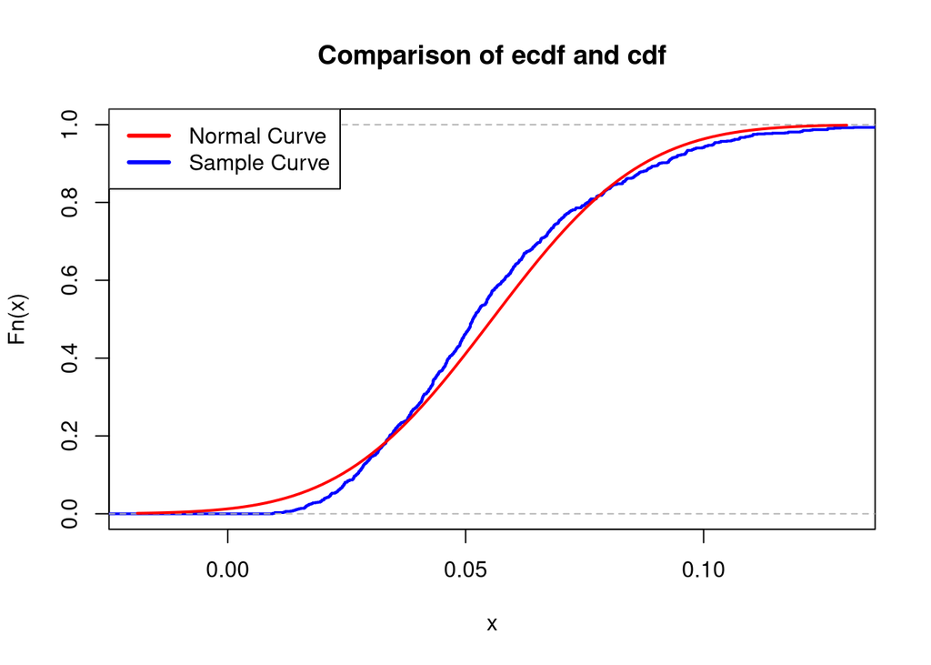

```r
xlims <- c(mu-3*sigma,mu+3*sigma)
Fs <- ecdf(sample_means)
plot(Fs,
     xlim = xlims,
     col = "blue",
     lwd = 2,
     main = "Comparison of ecdf and cdf")
curve(pnorm(x, mean = mu, sd = sigma), col = "red", lwd = 2, add = TRUE)
legend("topleft", legend = c("Normal Curve", "Sample Curve"), lwd = 3, col = c("red", "blue"))
```

```r
t <- vector("numeric",   length = n)
max(abs(Fs(t) - pnorm(t, mean = mu, sd = sigma)))
```

```
## [1] 0.01267366
```

**Number of clicks in one minute does not exceed 100 in terms of $S$ mean**

$S = X_1 + X_2 + ... +X_{100} \ge 60$

**Using Markov inequality, we can get that**

$P(S \ge 1) \le E(S)$

$E(S) = E(X_1) + E(X_2) + ... + E(X_{100}) = 100 * (\frac{1}{\lambda N}) = \frac{100}{18N}$

$P(S \ge 60) \le \frac{100}{18N}$

So, $\frac{100}{18N} \ge 0,95$

$N \le 5,84$

**Using Chebyshev’s inequality, we can get that**

$P(S \ge 1) = P(S-\frac{100}{18N} \ge 1-\frac{100}{18N}) \le P(|S-\frac{100}{18N}| \ge 1-\frac{100}{18N}) \le \frac{100(\frac{1}{18N})^{2}}{(1-\frac{100}{18N})} \ge 0,95$

So, $N \le 5,56$

**Using Central limit theorem we can get the following**

$P(S \ge 1) = 1 - P(S \le 1) = 1 - P(S-\frac{100}{18N} \le 1-\frac{100}{18N}) = P(\frac{S-\frac{100}{18N}}{\frac{1}{18N}*10} \le \frac{1-\frac{1}{18N}}{\frac{1}{18N}*10}) \approx 1 - \Phi(\frac{1-\frac{1}{18N}}{\frac{1}{18N}*10}) \ge 0,05$

So, $N \le 4,63$

```r
n <- 100
N <- 4.63
nu1 <- (nu1*(1/N))
s <- colSums(matrix(rexp(n*K, rate = 1/nu1), nrow=n))
print(s)
```

[output not shown]

[output cut: 128 more lines]

```r
print(mean(s))
```

```
## [1] 1.190236
```

```r
greter_1 = which(s > 1)
print(length(greter_1))
```

```
## [1] 951
```

```r
prob = length(greter_1)/(length(s))
print(prob)
```

```
## [1] 0.951
```